# Risk Factor Analysis

## Outcome Variable

**Outcome Variable:** ever_stunted

## Predictor Variables

**Intervention Variable:** perdiar24

**Adjustment Set:**

unadjusted

## Stratifying Variables

The analysis was stratified on these variable(s):

- agecat
- studyid
- country

## Data Summary

| agecat | studyid | country | perdiar24 | ever_stunted | n_cell | n |
| --- | --- | --- | --- | --- | --- | --- |
| 0-24 months (no birth st.) | ki0047075b-MAL-ED | BANGLADESH | (0%, 5%] | 0 | 63 | 217 |
| 0-24 months (no birth st.) | ki0047075b-MAL-ED | BANGLADESH | (0%, 5%] | 1 | 65 | 217 |
| 0-24 months (no birth st.) | ki0047075b-MAL-ED | BANGLADESH | >5% | 0 | 31 | 217 |
| 0-24 months (no birth st.) | ki0047075b-MAL-ED | BANGLADESH | >5% | 1 | 42 | 217 |
| 0-24 months (no birth st.) | ki0047075b-MAL-ED | BANGLADESH | 0% | 0 | 10 | 217 |
| 0-24 months (no birth st.) | ki0047075b-MAL-ED | BANGLADESH | 0% | 1 | 6 | 217 |
| 0-24 months (no birth st.) | ki0047075b-MAL-ED | BRAZIL | (0%, 5%] | 0 | 71 | 208 |
| 0-24 months (no birth st.) | ki0047075b-MAL-ED | BRAZIL | (0%, 5%] | 1 | 17 | 208 |
| 0-24 months (no birth st.) | ki0047075b-MAL-ED | BRAZIL | >5% | 0 | 2 | 208 |
| 0-24 months (no birth st.) | ki0047075b-MAL-ED | BRAZIL | >5% | 1 | 0 | 208 |
| 0-24 months (no birth st.) | ki0047075b-MAL-ED | BRAZIL | 0% | 0 | 106 | 208 |
| 0-24 months (no birth st.) | ki0047075b-MAL-ED | BRAZIL | 0% | 1 | 12 | 208 |
| 0-24 months (no birth st.) | ki0047075b-MAL-ED | INDIA | (0%, 5%] | 0 | 73 | 209 |
| 0-24 months (no birth st.) | ki0047075b-MAL-ED | INDIA | (0%, 5%] | 1 | 87 | 209 |
| 0-24 months (no birth st.) | ki0047075b-MAL-ED | INDIA | >5% | 0 | 19 | 209 |
| 0-24 months (no birth st.) | ki0047075b-MAL-ED | INDIA | >5% | 1 | 18 | 209 |
| 0-24 months (no birth st.) | ki0047075b-MAL-ED | INDIA | 0% | 0 | 9 | 209 |
| 0-24 months (no birth st.) | ki0047075b-MAL-ED | INDIA | 0% | 1 | 3 | 209 |
| 0-24 months (no birth st.) | ki0047075b-MAL-ED | NEPAL | (0%, 5%] | 0 | 95 | 212 |
| 0-24 months (no birth st.) | ki0047075b-MAL-ED | NEPAL | (0%, 5%] | 1 | 36 | 212 |
| 0-24 months (no birth st.) | ki0047075b-MAL-ED | NEPAL | >5% | 0 | 50 | 212 |
| 0-24 months (no birth st.) | ki0047075b-MAL-ED | NEPAL | >5% | 1 | 17 | 212 |
| 0-24 months (no birth st.) | ki0047075b-MAL-ED | NEPAL | 0% | 0 | 12 | 212 |
| 0-24 months (no birth st.) | ki0047075b-MAL-ED | NEPAL | 0% | 1 | 2 | 212 |
| 0-24 months (no birth st.) | ki0047075b-MAL-ED | PERU | (0%, 5%] | 0 | 34 | 266 |
| 0-24 months (no birth st.) | ki0047075b-MAL-ED | PERU | (0%, 5%] | 1 | 65 | 266 |
| 0-24 months (no birth st.) | ki0047075b-MAL-ED | PERU | >5% | 0 | 60 | 266 |
| 0-24 months (no birth st.) | ki0047075b-MAL-ED | PERU | >5% | 1 | 80 | 266 |
| 0-24 months (no birth st.) | ki0047075b-MAL-ED | PERU | 0% | 0 | 21 | 266 |
| 0-24 months (no birth st.) | ki0047075b-MAL-ED | PERU | 0% | 1 | 6 | 266 |

[output cut: 342 more lines]

The following strata were considered:

- agecat: 0-24 months (no birth st.), studyid: ki0047075b-MAL-ED, country: BANGLADESH
- agecat: 0-24 months (no birth st.), studyid: ki0047075b-MAL-ED, country: BRAZIL
- agecat: 0-24 months (no birth st.), studyid: ki0047075b-MAL-ED, country: INDIA
- agecat: 0-24 months (no birth st.), studyid: ki0047075b-MAL-ED, country: NEPAL
- agecat: 0-24 months (no birth st.), studyid: ki0047075b-MAL-ED, country: PERU
- agecat: 0-24 months (no birth st.), studyid: ki0047075b-MAL-ED, country: SOUTH AFRICA
- agecat: 0-24 months (no birth st.), studyid: ki0047075b-MAL-ED, country: TANZANIA, UNITED REPUBLIC OF
- agecat: 0-24 months (no birth st.), studyid: ki1000109-EE, country: PAKISTAN
- agecat: 0-24 months (no birth st.), studyid: ki1000109-ResPak, country: PAKISTAN
- agecat: 0-24 months (no birth st.), studyid: ki1000304b-SAS-FoodSuppl, country: INDIA
- agecat: 0-24 months (no birth st.), studyid: ki1017093-NIH-Birth, country: BANGLADESH
- agecat: 0-24 months (no birth st.), studyid: ki1017093b-PROVIDE, country: BANGLADESH
- agecat: 0-24 months (no birth st.), studyid: ki1017093c-NIH-Crypto, country: BANGLADESH
- agecat: 0-24 months (no birth st.), studyid: ki1112895-Guatemala BSC, country: GUATEMALA
- agecat: 0-24 months (no birth st.), studyid: ki1112895-iLiNS-Zinc, country: BURKINA FASO
- agecat: 0-24 months (no birth st.), studyid: ki1114097-CMIN, country: BANGLADESH
- agecat: 0-24 months (no birth st.), studyid: ki1114097-CMIN, country: BRAZIL
- agecat: 0-24 months (no birth st.), studyid: ki1114097-CMIN, country: GUINEA-BISSAU
- agecat: 0-24 months (no birth st.), studyid: ki1114097-CMIN, country: PERU
- agecat: 0-24 months (no birth st.), studyid: ki1114097-CONTENT, country: PERU
- agecat: 0-24 months (no birth st.), studyid: kiGH5241-JiVitA-4, country: BANGLADESH
- agecat: 0-6 months (no birth st.), studyid: ki0047075b-MAL-ED, country: BANGLADESH
- agecat: 0-6 months (no birth st.), studyid: ki0047075b-MAL-ED, country: BRAZIL
- agecat: 0-6 months (no birth st.), studyid: ki0047075b-MAL-ED, country: INDIA
- agecat: 0-6 months (no birth st.), studyid: ki0047075b-MAL-ED, country: NEPAL
- agecat: 0-6 months (no birth st.), studyid: ki0047075b-MAL-ED, country: PERU
- agecat: 0-6 months (no birth st.), studyid: ki0047075b-MAL-ED, country: SOUTH AFRICA
- agecat: 0-6 months (no birth st.), studyid: ki0047075b-MAL-ED, country: TANZANIA, UNITED REPUBLIC OF
- agecat: 0-6 months (no birth st.), studyid: ki1000109-EE, country: PAKISTAN
- agecat: 0-6 months (no birth st.), studyid: ki1000109-ResPak, country: PAKISTAN
- agecat: 0-6 months (no birth st.), studyid: ki1000304b-SAS-FoodSuppl, country: INDIA
- agecat: 0-6 months (no birth st.), studyid: ki1017093-NIH-Birth, country: BANGLADESH
- agecat: 0-6 months (no birth st.), studyid: ki1017093b-PROVIDE, country: BANGLADESH
- agecat: 0-6 months (no birth st.), studyid: ki1017093c-NIH-Crypto, country: BANGLADESH
- agecat: 0-6 months (no birth st.), studyid: ki1112895-Guatemala BSC, country: GUATEMALA
- agecat: 0-6 months (no birth st.), studyid: ki1114097-CMIN, country: BANGLADESH
- agecat: 0-6 months (no birth st.), studyid: ki1114097-CMIN, country: BRAZIL
- agecat: 0-6 months (no birth st.), studyid: ki1114097-CMIN, country: GUINEA-BISSAU
- agecat: 0-6 months (no birth st.), studyid: ki1114097-CMIN, country: PERU
- agecat: 0-6 months (no birth st.), studyid: ki1114097-CONTENT, country: PERU
- agecat: 0-6 months (no birth st.), studyid: kiGH5241-JiVitA-4, country: BANGLADESH
- agecat: 6-24 months, studyid: ki0047075b-MAL-ED, country: BANGLADESH
- agecat: 6-24 months, studyid: ki0047075b-MAL-ED, country: BRAZIL
- agecat: 6-24 months, studyid: ki0047075b-MAL-ED, country: INDIA
- agecat: 6-24 months, studyid: ki0047075b-MAL-ED, country: NEPAL
- agecat: 6-24 months, studyid: ki0047075b-MAL-ED, country: PERU
- agecat: 6-24 months, studyid: ki0047075b-MAL-ED, country: SOUTH AFRICA
- agecat: 6-24 months, studyid: ki0047075b-MAL-ED, country: TANZANIA, UNITED REPUBLIC OF
- agecat: 6-24 months, studyid: ki1000109-EE, country: PAKISTAN
- agecat: 6-24 months, studyid: ki1000109-ResPak, country: PAKISTAN
- agecat: 6-24 months, studyid: ki1000304b-SAS-FoodSuppl, country: INDIA
- agecat: 6-24 months, studyid: ki1017093-NIH-Birth, country: BANGLADESH
- agecat: 6-24 months, studyid: ki1017093b-PROVIDE, country: BANGLADESH
- agecat: 6-24 months, studyid: ki1017093c-NIH-Crypto, country: BANGLADESH
- agecat: 6-24 months, studyid: ki1112895-Guatemala BSC, country: GUATEMALA
- agecat: 6-24 months, studyid: ki1112895-iLiNS-Zinc, country: BURKINA FASO
- agecat: 6-24 months, studyid: ki1114097-CMIN, country: BANGLADESH
- agecat: 6-24 months, studyid: ki1114097-CMIN, country: BRAZIL
- agecat: 6-24 months, studyid: ki1114097-CMIN, country: GUINEA-BISSAU
- agecat: 6-24 months, studyid: ki1114097-CMIN, country: PERU
- agecat: 6-24 months, studyid: ki1114097-CONTENT, country: PERU
- agecat: 6-24 months, studyid: kiGH5241-JiVitA-4, country: BANGLADESH

### Dropped Strata

Some strata were dropped due to rare outcomes:

- agecat: 0-24 months (no birth st.), studyid: ki0047075b-MAL-ED, country: BRAZIL
- agecat: 0-24 months (no birth st.), studyid: ki0047075b-MAL-ED, country: INDIA
- agecat: 0-24 months (no birth st.), studyid: ki0047075b-MAL-ED, country: NEPAL
- agecat: 0-24 months (no birth st.), studyid: ki0047075b-MAL-ED, country: SOUTH AFRICA
- agecat: 0-24 months (no birth st.), studyid: ki1000109-EE, country: PAKISTAN
- agecat: 0-24 months (no birth st.), studyid: ki1017093b-PROVIDE, country: BANGLADESH
- agecat: 0-24 months (no birth st.), studyid: ki1114097-CMIN, country: BANGLADESH
- agecat: 0-24 months (no birth st.), studyid: ki1114097-CMIN, country: BRAZIL
- agecat: 0-24 months (no birth st.), studyid: ki1114097-CONTENT, country: PERU
- agecat: 0-6 months (no birth st.), studyid: ki0047075b-MAL-ED, country: BANGLADESH
- agecat: 0-6 months (no birth st.), studyid: ki0047075b-MAL-ED, country: BRAZIL
- agecat: 0-6 months (no birth st.), studyid: ki0047075b-MAL-ED, country: INDIA
- agecat: 0-6 months (no birth st.), studyid: ki0047075b-MAL-ED, country: NEPAL
- agecat: 0-6 months (no birth st.), studyid: ki0047075b-MAL-ED, country: SOUTH AFRICA
- agecat: 0-6 months (no birth st.), studyid: ki0047075b-MAL-ED, country: TANZANIA, UNITED REPUBLIC OF
- agecat: 0-6 months (no birth st.), studyid: ki1000304b-SAS-FoodSuppl, country: INDIA
- agecat: 0-6 months (no birth st.), studyid: ki1017093-NIH-Birth, country: BANGLADESH
- agecat: 0-6 months (no birth st.), studyid: ki1017093b-PROVIDE, country: BANGLADESH
- agecat: 0-6 months (no birth st.), studyid: ki1112895-Guatemala BSC, country: GUATEMALA
- agecat: 0-6 months (no birth st.), studyid: ki1114097-CMIN, country: BANGLADESH
- agecat: 0-6 months (no birth st.), studyid: ki1114097-CMIN, country: BRAZIL
- agecat: 0-6 months (no birth st.), studyid: ki1114097-CMIN, country: GUINEA-BISSAU
- agecat: 0-6 months (no birth st.), studyid: ki1114097-CMIN, country: PERU
- agecat: 0-6 months (no birth st.), studyid: ki1114097-CONTENT, country: PERU
- agecat: 6-24 months, studyid: ki0047075b-MAL-ED, country: BANGLADESH
- agecat: 6-24 months, studyid: ki0047075b-MAL-ED, country: BRAZIL
- agecat: 6-24 months, studyid: ki0047075b-MAL-ED, country: INDIA
- agecat: 6-24 months, studyid: ki0047075b-MAL-ED, country: NEPAL
- agecat: 6-24 months, studyid: ki0047075b-MAL-ED, country: PERU
- agecat: 6-24 months, studyid: ki0047075b-MAL-ED, country: SOUTH AFRICA
- agecat: 6-24 months, studyid: ki0047075b-MAL-ED, country: TANZANIA, UNITED REPUBLIC OF
- agecat: 6-24 months, studyid: ki1000109-EE, country: PAKISTAN
- agecat: 6-24 months, studyid: ki1000109-ResPak, country: PAKISTAN
- agecat: 6-24 months, studyid: ki1017093-NIH-Birth, country: BANGLADESH
- agecat: 6-24 months, studyid: ki1017093b-PROVIDE, country: BANGLADESH
- agecat: 6-24 months, studyid: ki1112895-Guatemala BSC, country: GUATEMALA
- agecat: 6-24 months, studyid: ki1114097-CMIN, country: BANGLADESH
- agecat: 6-24 months, studyid: ki1114097-CMIN, country: BRAZIL
- agecat: 6-24 months, studyid: ki1114097-CONTENT, country: PERU

## Methods Detail

We’re interested in the causal parameters $E[Y_a]$ for all values of $a \in \mathcal{A}$. These parameters represent the mean outcome if, possibly contrary to fact, we intervened to set all units to have $A=a$. Under the randomization and positivity assumptions, these are identified by the statistical parameters $\psi_a=E_W[E_{Y|A,W}(Y|A=a,W)]$. In addition, we’re interested in the mean of $Y$, $E[Y]$ under no intervention (the observed mean). We will estimate these parameters by using SuperLearner to fit the relevant likelihood factors – $E_{Y|A,W}(Y|A=a,W)$ and $p(A=a|W)$, and then updating our likelihood fit using a joint TMLE.

For unadjusted analyses ($W=\{\}$), initial likelihoods were estimated using Lrnr_glm to estimate the simple $E(Y|A)$ and Lrnr_mean to estimate $p(A)$. For adjusted analyses, a small library containing Lrnr_glmnet, Lrnr_xgboost, and Lrnr_mean was used.

Having estimated these parameters, we will then use the delta method to estimate relative risks and attributable risks relative to a prespecified baseline level of $A$.

# Results Detail

## Results Plots

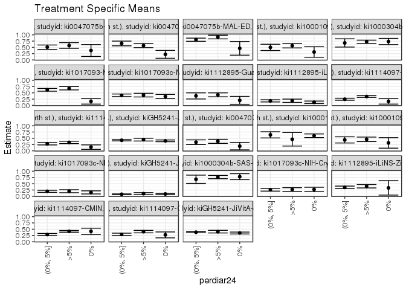

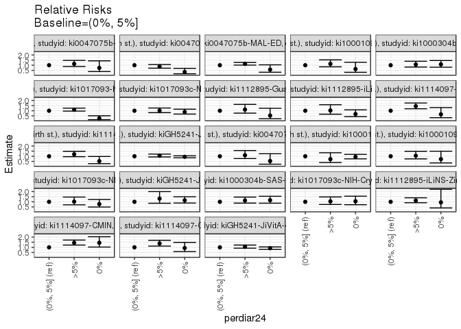

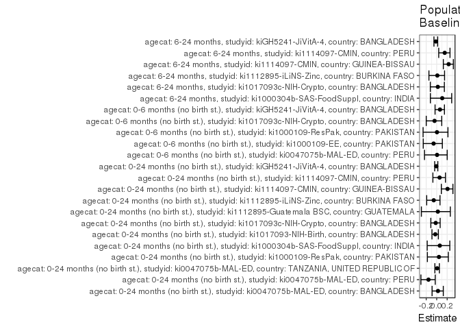

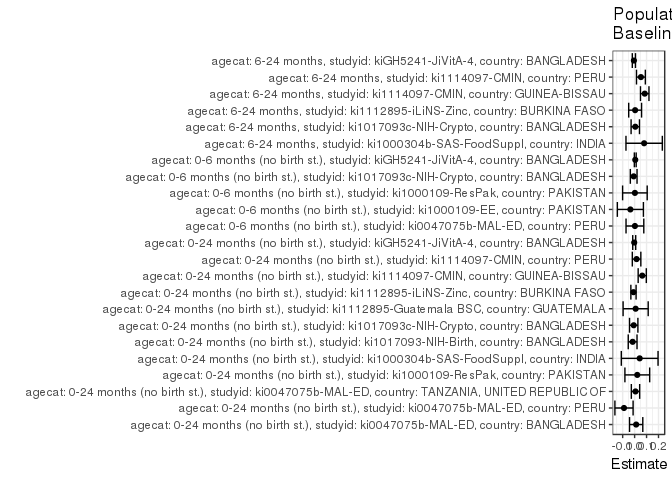

## Results Table

### Parameter: TSM

| agecat | studyid | country | intervention_level | baseline_level | estimate | ci_lower | ci_upper |
| --- | --- | --- | --- | --- | --- | --- | --- |
| 0-24 months (no birth st.) | ki0047075b-MAL-ED | BANGLADESH | (0%, 5%] | NA | 0.5078125 | 0.4210038 | 0.5946212 |
| 0-24 months (no birth st.) | ki0047075b-MAL-ED | BANGLADESH | >5% | NA | 0.5753425 | 0.4616917 | 0.6889932 |
| 0-24 months (no birth st.) | ki0047075b-MAL-ED | BANGLADESH | 0% | NA | 0.3750000 | 0.1372357 | 0.6127643 |
| 0-24 months (no birth st.) | ki0047075b-MAL-ED | PERU | (0%, 5%] | NA | 0.6565657 | 0.5628506 | 0.7502807 |
| 0-24 months (no birth st.) | ki0047075b-MAL-ED | PERU | >5% | NA | 0.5714286 | 0.4892999 | 0.6535572 |
| 0-24 months (no birth st.) | ki0047075b-MAL-ED | PERU | 0% | NA | 0.2222222 | 0.0651116 | 0.3793329 |
| 0-24 months (no birth st.) | ki0047075b-MAL-ED | TANZANIA, UNITED REPUBLIC OF | (0%, 5%] | NA | 0.8053691 | 0.7416526 | 0.8690857 |
| 0-24 months (no birth st.) | ki0047075b-MAL-ED | TANZANIA, UNITED REPUBLIC OF | >5% | NA | 0.9122807 | 0.8386742 | 0.9858872 |
| 0-24 months (no birth st.) | ki0047075b-MAL-ED | TANZANIA, UNITED REPUBLIC OF | 0% | NA | 0.4615385 | 0.1899249 | 0.7331521 |
| 0-24 months (no birth st.) | ki1000109-ResPak | PAKISTAN | (0%, 5%] | NA | 0.5000000 | 0.3752314 | 0.6247686 |
| 0-24 months (no birth st.) | ki1000109-ResPak | PAKISTAN | >5% | NA | 0.5666667 | 0.4777843 | 0.6555490 |
| 0-24 months (no birth st.) | ki1000109-ResPak | PAKISTAN | 0% | NA | 0.3157895 | 0.1062586 | 0.5253203 |
| 0-24 months (no birth st.) | ki1000304b-SAS-FoodSuppl | INDIA | (0%, 5%] | NA | 0.6774194 | 0.5125417 | 0.8422970 |
| 0-24 months (no birth st.) | ki1000304b-SAS-FoodSuppl | INDIA | >5% | NA | 0.7231638 | 0.6571192 | 0.7892085 |
| 0-24 months (no birth st.) | ki1000304b-SAS-FoodSuppl | INDIA | 0% | NA | 0.7346939 | 0.6108360 | 0.8585517 |
| 0-24 months (no birth st.) | ki1017093-NIH-Birth | BANGLADESH | (0%, 5%] | NA | 0.6208054 | 0.5656662 | 0.6759446 |
| 0-24 months (no birth st.) | ki1017093-NIH-Birth | BANGLADESH | >5% | NA | 0.6827957 | 0.6158507 | 0.7497407 |
| 0-24 months (no birth st.) | ki1017093-NIH-Birth | BANGLADESH | 0% | NA | 0.1590909 | 0.0509150 | 0.2672668 |
| 0-24 months (no birth st.) | ki1017093c-NIH-Crypto | BANGLADESH | (0%, 5%] | NA | 0.4011461 | 0.3496849 | 0.4526073 |
| 0-24 months (no birth st.) | ki1017093c-NIH-Crypto | BANGLADESH | >5% | NA | 0.4080460 | 0.3349649 | 0.4811270 |
| 0-24 months (no birth st.) | ki1017093c-NIH-Crypto | BANGLADESH | 0% | NA | 0.3538462 | 0.2715870 | 0.4361053 |
| 0-24 months (no birth st.) | ki1112895-Guatemala BSC | GUATEMALA | (0%, 5%] | NA | 0.3770492 | 0.2551696 | 0.4989288 |
| 0-24 months (no birth st.) | ki1112895-Guatemala BSC | GUATEMALA | >5% | NA | 0.4200000 | 0.3408478 | 0.4991522 |
| 0-24 months (no birth st.) | ki1112895-Guatemala BSC | GUATEMALA | 0% | NA | 0.2000000 | 0.0428696 | 0.3571304 |
| 0-24 months (no birth st.) | ki1112895-iLiNS-Zinc | BURKINA FASO | (0%, 5%] | NA | 0.1792144 | 0.1363781 | 0.2220507 |
| 0-24 months (no birth st.) | ki1112895-iLiNS-Zinc | BURKINA FASO | >5% | NA | 0.1840491 | 0.1182346 | 0.2498635 |
| 0-24 months (no birth st.) | ki1112895-iLiNS-Zinc | BURKINA FASO | 0% | NA | 0.1220930 | 0.0722371 | 0.1719490 |
| 0-24 months (no birth st.) | ki1114097-CMIN | GUINEA-BISSAU | (0%, 5%] | NA | 0.2447552 | 0.2040541 | 0.2854564 |
| 0-24 months (no birth st.) | ki1114097-CMIN | GUINEA-BISSAU | >5% | NA | 0.3537234 | 0.3195367 | 0.3879101 |
| 0-24 months (no birth st.) | ki1114097-CMIN | GUINEA-BISSAU | 0% | NA | 0.1590909 | 0.0509733 | 0.2672085 |
| 0-24 months (no birth st.) | ki1114097-CMIN | PERU | (0%, 5%] | NA | 0.2812500 | 0.2342517 | 0.3282483 |
| 0-24 months (no birth st.) | ki1114097-CMIN | PERU | >5% | NA | 0.3358974 | 0.2889937 | 0.3828012 |
| 0-24 months (no birth st.) | ki1114097-CMIN | PERU | 0% | NA | 0.1475410 | 0.0584883 | 0.2365936 |
| 0-24 months (no birth st.) | kiGH5241-JiVitA-4 | BANGLADESH | (0%, 5%] | NA | 0.4202008 | 0.3979565 | 0.4424451 |
| 0-24 months (no birth st.) | kiGH5241-JiVitA-4 | BANGLADESH | >5% | NA | 0.4467153 | 0.3918734 | 0.5015572 |
| 0-24 months (no birth st.) | kiGH5241-JiVitA-4 | BANGLADESH | 0% | NA | 0.3981809 | 0.3631272 | 0.4332346 |
| 0-6 months (no birth st.) | ki0047075b-MAL-ED | PERU | (0%, 5%] | NA | 0.3434343 | 0.2497193 | 0.4371494 |
| 0-6 months (no birth st.) | ki0047075b-MAL-ED | PERU | >5% | NA | 0.3785714 | 0.2980760 | 0.4590669 |
| 0-6 months (no birth st.) | ki0047075b-MAL-ED | PERU | 0% | NA | 0.1851852 | 0.0383884 | 0.3319820 |
| 0-6 months (no birth st.) | ki1000109-EE | PAKISTAN | (0%, 5%] | NA | 0.6379310 | 0.5139970 | 0.7618650 |
| 0-6 months (no birth st.) | ki1000109-EE | PAKISTAN | >5% | NA | 0.4615385 | 0.1899999 | 0.7330770 |
| 0-6 months (no birth st.) | ki1000109-EE | PAKISTAN | 0% | NA | 0.6011236 | 0.5290439 | 0.6732033 |
| 0-6 months (no birth st.) | ki1000109-ResPak | PAKISTAN | (0%, 5%] | NA | 0.4354839 | 0.3117583 | 0.5592094 |
| 0-6 months (no birth st.) | ki1000109-ResPak | PAKISTAN | >5% | NA | 0.4583333 | 0.3689622 | 0.5477045 |
| 0-6 months (no birth st.) | ki1000109-ResPak | PAKISTAN | 0% | NA | 0.3157895 | 0.1062586 | 0.5253203 |
| 0-6 months (no birth st.) | ki1017093c-NIH-Crypto | BANGLADESH | (0%, 5%] | NA | 0.1977077 | 0.1558914 | 0.2395241 |
| 0-6 months (no birth st.) | ki1017093c-NIH-Crypto | BANGLADESH | >5% | NA | 0.2011494 | 0.1415423 | 0.2607566 |
| 0-6 months (no birth st.) | ki1017093c-NIH-Crypto | BANGLADESH | 0% | NA | 0.1538462 | 0.0917768 | 0.2159155 |
| 0-6 months (no birth st.) | kiGH5241-JiVitA-4 | BANGLADESH | (0%, 5%] | NA | 0.0802026 | 0.0667850 | 0.0936202 |
| 0-6 months (no birth st.) | kiGH5241-JiVitA-4 | BANGLADESH | >5% | NA | 0.1051051 | 0.0647315 | 0.1454787 |
| 0-6 months (no birth st.) | kiGH5241-JiVitA-4 | BANGLADESH | 0% | NA | 0.0919540 | 0.0710542 | 0.1128538 |
| 6-24 months | ki1000304b-SAS-FoodSuppl | INDIA | (0%, 5%] | NA | 0.6774194 | 0.5125232 | 0.8423156 |
| 6-24 months | ki1000304b-SAS-FoodSuppl | INDIA | >5% | NA | 0.7650602 | 0.7004330 | 0.8296875 |
| 6-24 months | ki1000304b-SAS-FoodSuppl | INDIA | 0% | NA | 0.7826087 | 0.6631664 | 0.9020510 |
| 6-24 months | ki1017093c-NIH-Crypto | BANGLADESH | (0%, 5%] | NA | 0.2572464 | 0.2056261 | 0.3088666 |
| 6-24 months | ki1017093c-NIH-Crypto | BANGLADESH | >5% | NA | 0.2686567 | 0.1935317 | 0.3437818 |
| 6-24 months | ki1017093c-NIH-Crypto | BANGLADESH | 0% | NA | 0.2708333 | 0.1818504 | 0.3598162 |
| 6-24 months | ki1112895-iLiNS-Zinc | BURKINA FASO | (0%, 5%] | NA | 0.3549839 | 0.3035541 | 0.4064137 |
| 6-24 months | ki1112895-iLiNS-Zinc | BURKINA FASO | >5% | NA | 0.3995485 | 0.3324993 | 0.4665978 |
| 6-24 months | ki1112895-iLiNS-Zinc | BURKINA FASO | 0% | NA | 0.3348018 | 0.0475439 | 0.6220596 |
| 6-24 months | ki1114097-CMIN | GUINEA-BISSAU | (0%, 5%] | NA | 0.2860360 | 0.2439857 | 0.3280864 |
| 6-24 months | ki1114097-CMIN | GUINEA-BISSAU | >5% | NA | 0.4134146 | 0.3796965 | 0.4471328 |
| 6-24 months | ki1114097-CMIN | GUINEA-BISSAU | 0% | NA | 0.4137931 | 0.2869942 | 0.5405920 |
| 6-24 months | ki1114097-CMIN | PERU | (0%, 5%] | NA | 0.2922636 | 0.2445183 | 0.3400090 |
| 6-24 months | ki1114097-CMIN | PERU | >5% | NA | 0.4020356 | 0.3535297 | 0.4505415 |
| 6-24 months | ki1114097-CMIN | PERU | 0% | NA | 0.2727273 | 0.1549525 | 0.3905021 |
| 6-24 months | kiGH5241-JiVitA-4 | BANGLADESH | (0%, 5%] | NA | 0.3792345 | 0.3561641 | 0.4023049 |
| 6-24 months | kiGH5241-JiVitA-4 | BANGLADESH | >5% | NA | 0.4012638 | 0.3481986 | 0.4543290 |
| 6-24 months | kiGH5241-JiVitA-4 | BANGLADESH | 0% | NA | 0.3482340 | 0.3105774 | 0.3858906 |

### Parameter: E(Y)

| agecat | studyid | country | intervention_level | baseline_level | estimate | ci_lower | ci_upper |
| --- | --- | --- | --- | --- | --- | --- | --- |
| 0-24 months (no birth st.) | ki0047075b-MAL-ED | BANGLADESH | NA | NA | 0.5207373 | 0.4541154 | 0.5873593 |
| 0-24 months (no birth st.) | ki0047075b-MAL-ED | PERU | NA | NA | 0.5676692 | 0.5080232 | 0.6273151 |
| 0-24 months (no birth st.) | ki0047075b-MAL-ED | TANZANIA, UNITED REPUBLIC OF | NA | NA | 0.8127854 | 0.7610035 | 0.8645672 |
| 0-24 months (no birth st.) | ki1000109-ResPak | PAKISTAN | NA | NA | 0.5223881 | 0.4531624 | 0.5916138 |
| 0-24 months (no birth st.) | ki1000304b-SAS-FoodSuppl | INDIA | NA | NA | 0.7198444 | 0.6648337 | 0.7748550 |
| 0-24 months (no birth st.) | ki1017093-NIH-Birth | BANGLADESH | NA | NA | 0.6041667 | 0.5624147 | 0.6459187 |
| 0-24 months (no birth st.) | ki1017093c-NIH-Crypto | BANGLADESH | NA | NA | 0.3935681 | 0.3560687 | 0.4310676 |
| 0-24 months (no birth st.) | ki1112895-Guatemala BSC | GUATEMALA | NA | NA | 0.3855932 | 0.3233622 | 0.4478242 |
| 0-24 months (no birth st.) | ki1112895-iLiNS-Zinc | BURKINA FASO | NA | NA | 0.1696617 | 0.1377362 | 0.2015872 |
| 0-24 months (no birth st.) | ki1114097-CMIN | GUINEA-BISSAU | NA | NA | 0.3085714 | 0.2826947 | 0.3344481 |
| 0-24 months (no birth st.) | ki1114097-CMIN | PERU | NA | NA | 0.2976339 | 0.2659904 | 0.3292773 |
| 0-24 months (no birth st.) | kiGH5241-JiVitA-4 | BANGLADESH | NA | NA | 0.4168323 | 0.3985283 | 0.4351363 |
| 0-6 months (no birth st.) | ki0047075b-MAL-ED | PERU | NA | NA | 0.3458647 | 0.2885967 | 0.4031327 |
| 0-6 months (no birth st.) | ki1000109-EE | PAKISTAN | NA | NA | 0.6024096 | 0.5415000 | 0.6633193 |
| 0-6 months (no birth st.) | ki1000109-ResPak | PAKISTAN | NA | NA | 0.4378109 | 0.3690538 | 0.5065681 |
| 0-6 months (no birth st.) | ki1017093c-NIH-Crypto | BANGLADESH | NA | NA | 0.1898928 | 0.1597870 | 0.2199986 |
| 0-6 months (no birth st.) | kiGH5241-JiVitA-4 | BANGLADESH | NA | NA | 0.0855425 | 0.0741829 | 0.0969021 |
| 6-24 months | ki1000304b-SAS-FoodSuppl | INDIA | NA | NA | 0.7572016 | 0.7031798 | 0.8112234 |
| 6-24 months | ki1017093c-NIH-Crypto | BANGLADESH | NA | NA | 0.2628458 | 0.2244546 | 0.3012371 |
| 6-24 months | ki1112895-iLiNS-Zinc | BURKINA FASO | NA | NA | 0.3592985 | 0.2940547 | 0.4245424 |
| 6-24 months | ki1114097-CMIN | GUINEA-BISSAU | NA | NA | 0.3706505 | 0.3446055 | 0.3966956 |
| 6-24 months | ki1114097-CMIN | PERU | NA | NA | 0.3450439 | 0.3120195 | 0.3780683 |
| 6-24 months | kiGH5241-JiVitA-4 | BANGLADESH | NA | NA | 0.3731941 | 0.3544912 | 0.3918971 |

### Parameter: RR

| agecat | studyid | country | intervention_level | baseline_level | estimate | ci_lower | ci_upper |
| --- | --- | --- | --- | --- | --- | --- | --- |
| 0-24 months (no birth st.) | ki0047075b-MAL-ED | BANGLADESH | (0%, 5%] | (0%, 5%] | 1.0000000 | 1.0000000 | 1.0000000 |
| 0-24 months (no birth st.) | ki0047075b-MAL-ED | BANGLADESH | >5% | (0%, 5%] | 1.1329821 | 0.8725106 | 1.4712124 |
| 0-24 months (no birth st.) | ki0047075b-MAL-ED | BANGLADESH | 0% | (0%, 5%] | 0.7384615 | 0.3829445 | 1.4240325 |
| 0-24 months (no birth st.) | ki0047075b-MAL-ED | PERU | (0%, 5%] | (0%, 5%] | 1.0000000 | 1.0000000 | 1.0000000 |
| 0-24 months (no birth st.) | ki0047075b-MAL-ED | PERU | >5% | (0%, 5%] | 0.8703297 | 0.7107444 | 1.0657471 |
| 0-24 months (no birth st.) | ki0047075b-MAL-ED | PERU | 0% | (0%, 5%] | 0.3384615 | 0.1645391 | 0.6962249 |
| 0-24 months (no birth st.) | ki0047075b-MAL-ED | TANZANIA, UNITED REPUBLIC OF | (0%, 5%] | (0%, 5%] | 1.0000000 | 1.0000000 | 1.0000000 |
| 0-24 months (no birth st.) | ki0047075b-MAL-ED | TANZANIA, UNITED REPUBLIC OF | >5% | (0%, 5%] | 1.1327485 | 1.0117149 | 1.2682617 |
| 0-24 months (no birth st.) | ki0047075b-MAL-ED | TANZANIA, UNITED REPUBLIC OF | 0% | (0%, 5%] | 0.5730769 | 0.3164704 | 1.0377500 |
| 0-24 months (no birth st.) | ki1000109-ResPak | PAKISTAN | (0%, 5%] | (0%, 5%] | 1.0000000 | 1.0000000 | 1.0000000 |
| 0-24 months (no birth st.) | ki1000109-ResPak | PAKISTAN | >5% | (0%, 5%] | 1.1333333 | 0.8440227 | 1.5218127 |
| 0-24 months (no birth st.) | ki1000109-ResPak | PAKISTAN | 0% | (0%, 5%] | 0.6315789 | 0.3108580 | 1.2831965 |
| 0-24 months (no birth st.) | ki1000304b-SAS-FoodSuppl | INDIA | (0%, 5%] | (0%, 5%] | 1.0000000 | 1.0000000 | 1.0000000 |
| 0-24 months (no birth st.) | ki1000304b-SAS-FoodSuppl | INDIA | >5% | (0%, 5%] | 1.0675276 | 0.8231508 | 1.3844548 |
| 0-24 months (no birth st.) | ki1000304b-SAS-FoodSuppl | INDIA | 0% | (0%, 5%] | 1.0845481 | 0.8066136 | 1.4582503 |
| 0-24 months (no birth st.) | ki1017093-NIH-Birth | BANGLADESH | (0%, 5%] | (0%, 5%] | 1.0000000 | 1.0000000 | 1.0000000 |
| 0-24 months (no birth st.) | ki1017093-NIH-Birth | BANGLADESH | >5% | (0%, 5%] | 1.0998547 | 0.9635645 | 1.2554223 |
| 0-24 months (no birth st.) | ki1017093-NIH-Birth | BANGLADESH | 0% | (0%, 5%] | 0.2562654 | 0.1290854 | 0.5087480 |
| 0-24 months (no birth st.) | ki1017093c-NIH-Crypto | BANGLADESH | (0%, 5%] | (0%, 5%] | 1.0000000 | 1.0000000 | 1.0000000 |
| 0-24 months (no birth st.) | ki1017093c-NIH-Crypto | BANGLADESH | >5% | (0%, 5%] | 1.0172003 | 0.8160740 | 1.2678954 |
| 0-24 months (no birth st.) | ki1017093c-NIH-Crypto | BANGLADESH | 0% | (0%, 5%] | 0.8820879 | 0.6763921 | 1.1503373 |
| 0-24 months (no birth st.) | ki1112895-Guatemala BSC | GUATEMALA | (0%, 5%] | (0%, 5%] | 1.0000000 | 1.0000000 | 1.0000000 |
| 0-24 months (no birth st.) | ki1112895-Guatemala BSC | GUATEMALA | >5% | (0%, 5%] | 1.1139130 | 0.7662151 | 1.6193916 |
| 0-24 months (no birth st.) | ki1112895-Guatemala BSC | GUATEMALA | 0% | (0%, 5%] | 0.5304348 | 0.2268176 | 1.2404729 |
| 0-24 months (no birth st.) | ki1112895-iLiNS-Zinc | BURKINA FASO | (0%, 5%] | (0%, 5%] | 1.0000000 | 1.0000000 | 1.0000000 |
| 0-24 months (no birth st.) | ki1112895-iLiNS-Zinc | BURKINA FASO | >5% | (0%, 5%] | 1.0269771 | 0.6644908 | 1.5872032 |
| 0-24 months (no birth st.) | ki1112895-iLiNS-Zinc | BURKINA FASO | 0% | (0%, 5%] | 0.6812679 | 0.4256095 | 1.0904973 |
| 0-24 months (no birth st.) | ki1114097-CMIN | GUINEA-BISSAU | (0%, 5%] | (0%, 5%] | 1.0000000 | 1.0000000 | 1.0000000 |
| 0-24 months (no birth st.) | ki1114097-CMIN | GUINEA-BISSAU | >5% | (0%, 5%] | 1.4452128 | 1.1923396 | 1.7517156 |
| 0-24 months (no birth st.) | ki1114097-CMIN | GUINEA-BISSAU | 0% | (0%, 5%] | 0.6500000 | 0.3228948 | 1.3084759 |
| 0-24 months (no birth st.) | ki1114097-CMIN | PERU | (0%, 5%] | (0%, 5%] | 1.0000000 | 1.0000000 | 1.0000000 |
| 0-24 months (no birth st.) | ki1114097-CMIN | PERU | >5% | (0%, 5%] | 1.1943020 | 0.9605920 | 1.4848731 |
| 0-24 months (no birth st.) | ki1114097-CMIN | PERU | 0% | (0%, 5%] | 0.5245902 | 0.2804325 | 0.9813228 |
| 0-24 months (no birth st.) | kiGH5241-JiVitA-4 | BANGLADESH | (0%, 5%] | (0%, 5%] | 1.0000000 | 1.0000000 | 1.0000000 |
| 0-24 months (no birth st.) | kiGH5241-JiVitA-4 | BANGLADESH | >5% | (0%, 5%] | 1.0630997 | 0.9337857 | 1.2103216 |
| 0-24 months (no birth st.) | kiGH5241-JiVitA-4 | BANGLADESH | 0% | (0%, 5%] | 0.9475968 | 0.8566601 | 1.0481866 |
| 0-6 months (no birth st.) | ki0047075b-MAL-ED | PERU | (0%, 5%] | (0%, 5%] | 1.0000000 | 1.0000000 | 1.0000000 |
| 0-6 months (no birth st.) | ki0047075b-MAL-ED | PERU | >5% | (0%, 5%] | 1.1023109 | 0.7799475 | 1.5579117 |
| 0-6 months (no birth st.) | ki0047075b-MAL-ED | PERU | 0% | (0%, 5%] | 0.5392157 | 0.2331683 | 1.2469686 |
| 0-6 months (no birth st.) | ki1000109-EE | PAKISTAN | (0%, 5%] | (0%, 5%] | 1.0000000 | 1.0000000 | 1.0000000 |
| 0-6 months (no birth st.) | ki1000109-EE | PAKISTAN | >5% | (0%, 5%] | 0.7234927 | 0.3893625 | 1.3443559 |
| 0-6 months (no birth st.) | ki1000109-EE | PAKISTAN | 0% | (0%, 5%] | 0.9423019 | 0.7499646 | 1.1839663 |
| 0-6 months (no birth st.) | ki1000109-ResPak | PAKISTAN | (0%, 5%] | (0%, 5%] | 1.0000000 | 1.0000000 | 1.0000000 |
| 0-6 months (no birth st.) | ki1000109-ResPak | PAKISTAN | >5% | (0%, 5%] | 1.0524691 | 0.7456876 | 1.4854629 |
| 0-6 months (no birth st.) | ki1000109-ResPak | PAKISTAN | 0% | (0%, 5%] | 0.7251462 | 0.3523379 | 1.4924226 |
| 0-6 months (no birth st.) | ki1017093c-NIH-Crypto | BANGLADESH | (0%, 5%] | (0%, 5%] | 1.0000000 | 1.0000000 | 1.0000000 |
| 0-6 months (no birth st.) | ki1017093c-NIH-Crypto | BANGLADESH | >5% | (0%, 5%] | 1.0174080 | 0.7069375 | 1.4642299 |
| 0-6 months (no birth st.) | ki1017093c-NIH-Crypto | BANGLADESH | 0% | (0%, 5%] | 0.7781494 | 0.4934339 | 1.2271482 |
| 0-6 months (no birth st.) | kiGH5241-JiVitA-4 | BANGLADESH | (0%, 5%] | (0%, 5%] | 1.0000000 | 1.0000000 | 1.0000000 |
| 0-6 months (no birth st.) | kiGH5241-JiVitA-4 | BANGLADESH | >5% | (0%, 5%] | 1.3104947 | 0.8603144 | 1.9962427 |
| 0-6 months (no birth st.) | kiGH5241-JiVitA-4 | BANGLADESH | 0% | (0%, 5%] | 1.1465215 | 0.8806410 | 1.4926758 |
| 6-24 months | ki1000304b-SAS-FoodSuppl | INDIA | (0%, 5%] | (0%, 5%] | 1.0000000 | 1.0000000 | 1.0000000 |
| 6-24 months | ki1000304b-SAS-FoodSuppl | INDIA | >5% | (0%, 5%] | 1.1293746 | 0.8728470 | 1.4612951 |
| 6-24 months | ki1000304b-SAS-FoodSuppl | INDIA | 0% | (0%, 5%] | 1.1552795 | 0.8667844 | 1.5397955 |
| 6-24 months | ki1017093c-NIH-Crypto | BANGLADESH | (0%, 5%] | (0%, 5%] | 1.0000000 | 1.0000000 | 1.0000000 |
| 6-24 months | ki1017093c-NIH-Crypto | BANGLADESH | >5% | (0%, 5%] | 1.0443557 | 0.7402401 | 1.4734122 |
| 6-24 months | ki1017093c-NIH-Crypto | BANGLADESH | 0% | (0%, 5%] | 1.0528169 | 0.7164012 | 1.5472104 |
| 6-24 months | ki1112895-iLiNS-Zinc | BURKINA FASO | (0%, 5%] | (0%, 5%] | 1.0000000 | 1.0000000 | 1.0000000 |
| 6-24 months | ki1112895-iLiNS-Zinc | BURKINA FASO | >5% | (0%, 5%] | 1.1255398 | 0.9104224 | 1.3914857 |
| 6-24 months | ki1112895-iLiNS-Zinc | BURKINA FASO | 0% | (0%, 5%] | 0.9431463 | 0.4006779 | 2.2200497 |
| 6-24 months | ki1114097-CMIN | GUINEA-BISSAU | (0%, 5%] | (0%, 5%] | 1.0000000 | 1.0000000 | 1.0000000 |
| 6-24 months | ki1114097-CMIN | GUINEA-BISSAU | >5% | (0%, 5%] | 1.4453236 | 1.2216638 | 1.7099306 |
| 6-24 months | ki1114097-CMIN | GUINEA-BISSAU | 0% | (0%, 5%] | 1.4466468 | 1.0298137 | 2.0321995 |
| 6-24 months | ki1114097-CMIN | PERU | (0%, 5%] | (0%, 5%] | 1.0000000 | 1.0000000 | 1.0000000 |
| 6-24 months | ki1114097-CMIN | PERU | >5% | (0%, 5%] | 1.3755925 | 1.1227684 | 1.6853473 |
| 6-24 months | ki1114097-CMIN | PERU | 0% | (0%, 5%] | 0.9331551 | 0.5880802 | 1.4807137 |
| 6-24 months | kiGH5241-JiVitA-4 | BANGLADESH | (0%, 5%] | (0%, 5%] | 1.0000000 | 1.0000000 | 1.0000000 |
| 6-24 months | kiGH5241-JiVitA-4 | BANGLADESH | >5% | (0%, 5%] | 1.0580889 | 0.9164676 | 1.2215950 |
| 6-24 months | kiGH5241-JiVitA-4 | BANGLADESH | 0% | (0%, 5%] | 0.9182551 | 0.8116044 | 1.0389205 |

### Parameter: PAR

| agecat | studyid | country | intervention_level | baseline_level | estimate | ci_lower | ci_upper |
| --- | --- | --- | --- | --- | --- | --- | --- |
| 0-24 months (no birth st.) | ki0047075b-MAL-ED | BANGLADESH | (0%, 5%] | NA | 0.0129248 | -0.0426102 | 0.0684598 |
| 0-24 months (no birth st.) | ki0047075b-MAL-ED | PERU | (0%, 5%] | NA | -0.0888965 | -0.1650725 | -0.0127204 |
| 0-24 months (no birth st.) | ki0047075b-MAL-ED | TANZANIA, UNITED REPUBLIC OF | (0%, 5%] | NA | 0.0074163 | -0.0274674 | 0.0422999 |
| 0-24 months (no birth st.) | ki1000109-ResPak | PAKISTAN | (0%, 5%] | NA | 0.0223881 | -0.0813219 | 0.1260980 |
| 0-24 months (no birth st.) | ki1000304b-SAS-FoodSuppl | INDIA | (0%, 5%] | NA | 0.0424250 | -0.1113692 | 0.1962192 |
| 0-24 months (no birth st.) | ki1017093-NIH-Birth | BANGLADESH | (0%, 5%] | NA | -0.0166387 | -0.0534038 | 0.0201264 |
| 0-24 months (no birth st.) | ki1017093c-NIH-Crypto | BANGLADESH | (0%, 5%] | NA | -0.0075780 | -0.0425596 | 0.0274036 |
| 0-24 months (no birth st.) | ki1112895-Guatemala BSC | GUATEMALA | (0%, 5%] | NA | 0.0085440 | -0.0965666 | 0.1136547 |
| 0-24 months (no birth st.) | ki1112895-iLiNS-Zinc | BURKINA FASO | (0%, 5%] | NA | -0.0095527 | -0.0314324 | 0.0123270 |
| 0-24 months (no birth st.) | ki1114097-CMIN | GUINEA-BISSAU | (0%, 5%] | NA | 0.0638162 | 0.0296709 | 0.0979615 |
| 0-24 months (no birth st.) | ki1114097-CMIN | PERU | (0%, 5%] | NA | 0.0163839 | -0.0193041 | 0.0520718 |
| 0-24 months (no birth st.) | kiGH5241-JiVitA-4 | BANGLADESH | (0%, 5%] | NA | -0.0033684 | -0.0158311 | 0.0090942 |
| 0-6 months (no birth st.) | ki0047075b-MAL-ED | PERU | (0%, 5%] | NA | 0.0024303 | -0.0718985 | 0.0767592 |
| 0-6 months (no birth st.) | ki1000109-EE | PAKISTAN | (0%, 5%] | NA | -0.0355214 | -0.1446733 | 0.0736305 |
| 0-6 months (no birth st.) | ki1000109-ResPak | PAKISTAN | (0%, 5%] | NA | 0.0023271 | -0.1005894 | 0.1052436 |
| 0-6 months (no birth st.) | ki1017093c-NIH-Crypto | BANGLADESH | (0%, 5%] | NA | -0.0078149 | -0.0358481 | 0.0202182 |
| 0-6 months (no birth st.) | kiGH5241-JiVitA-4 | BANGLADESH | (0%, 5%] | NA | 0.0053399 | -0.0023074 | 0.0129872 |
| 6-24 months | ki1000304b-SAS-FoodSuppl | INDIA | (0%, 5%] | NA | 0.0797823 | -0.0724398 | 0.2320043 |
| 6-24 months | ki1017093c-NIH-Crypto | BANGLADESH | (0%, 5%] | NA | 0.0055995 | -0.0294953 | 0.0406943 |
| 6-24 months | ki1112895-iLiNS-Zinc | BURKINA FASO | (0%, 5%] | NA | 0.0043146 | -0.0495727 | 0.0582019 |
| 6-24 months | ki1114097-CMIN | GUINEA-BISSAU | (0%, 5%] | NA | 0.0846145 | 0.0491344 | 0.1200946 |
| 6-24 months | ki1114097-CMIN | PERU | (0%, 5%] | NA | 0.0527803 | 0.0157158 | 0.0898448 |
| 6-24 months | kiGH5241-JiVitA-4 | BANGLADESH | (0%, 5%] | NA | -0.0060404 | -0.0193704 | 0.0072896 |

### Parameter: PAF

| agecat | studyid | country | intervention_level | baseline_level | estimate | ci_lower | ci_upper |
| --- | --- | --- | --- | --- | --- | --- | --- |
| 0-24 months (no birth st.) | ki0047075b-MAL-ED | BANGLADESH | (0%, 5%] | NA | 0.0248202 | -0.0879356 | 0.1258899 |
| 0-24 months (no birth st.) | ki0047075b-MAL-ED | PERU | (0%, 5%] | NA | -0.1565991 | -0.3011772 | -0.0280855 |
| 0-24 months (no birth st.) | ki0047075b-MAL-ED | TANZANIA, UNITED REPUBLIC OF | (0%, 5%] | NA | 0.0091245 | -0.0347684 | 0.0511556 |
| 0-24 months (no birth st.) | ki1000109-ResPak | PAKISTAN | (0%, 5%] | NA | 0.0428571 | -0.1778728 | 0.2222229 |
| 0-24 months (no birth st.) | ki1000304b-SAS-FoodSuppl | INDIA | (0%, 5%] | NA | 0.0589364 | -0.1811381 | 0.2502140 |
| 0-24 months (no birth st.) | ki1017093-NIH-Birth | BANGLADESH | (0%, 5%] | NA | -0.0275399 | -0.0902979 | 0.0316057 |
| 0-24 months (no birth st.) | ki1017093c-NIH-Crypto | BANGLADESH | (0%, 5%] | NA | -0.0192546 | -0.1121351 | 0.0658690 |
| 0-24 months (no birth st.) | ki1112895-Guatemala BSC | GUATEMALA | (0%, 5%] | NA | 0.0221582 | -0.2922305 | 0.2600588 |
| 0-24 months (no birth st.) | ki1112895-iLiNS-Zinc | BURKINA FASO | (0%, 5%] | NA | -0.0563042 | -0.1910540 | 0.0632007 |
| 0-24 months (no birth st.) | ki1114097-CMIN | GUINEA-BISSAU | (0%, 5%] | NA | 0.2068117 | 0.0885221 | 0.3097499 |
| 0-24 months (no birth st.) | ki1114097-CMIN | PERU | (0%, 5%] | NA | 0.0550471 | -0.0727659 | 0.1676320 |
| 0-24 months (no birth st.) | kiGH5241-JiVitA-4 | BANGLADESH | (0%, 5%] | NA | -0.0080810 | -0.0384260 | 0.0213771 |
| 0-6 months (no birth st.) | ki0047075b-MAL-ED | PERU | (0%, 5%] | NA | 0.0070268 | -0.2329093 | 0.2002690 |
| 0-6 months (no birth st.) | ki1000109-EE | PAKISTAN | (0%, 5%] | NA | -0.0589655 | -0.2568391 | 0.1077553 |
| 0-6 months (no birth st.) | ki1000109-ResPak | PAKISTAN | (0%, 5%] | NA | 0.0053152 | -0.2598569 | 0.2146745 |
| 0-6 months (no birth st.) | ki1017093c-NIH-Crypto | BANGLADESH | (0%, 5%] | NA | -0.0411545 | -0.1996742 | 0.0964192 |
| 0-6 months (no birth st.) | kiGH5241-JiVitA-4 | BANGLADESH | (0%, 5%] | NA | 0.0624237 | -0.0314046 | 0.1477163 |
| 6-24 months | ki1000304b-SAS-FoodSuppl | INDIA | (0%, 5%] | NA | 0.1053647 | -0.1208508 | 0.2859242 |
| 6-24 months | ki1017093c-NIH-Crypto | BANGLADESH | (0%, 5%] | NA | 0.0213033 | -0.1217391 | 0.1461051 |
| 6-24 months | ki1112895-iLiNS-Zinc | BURKINA FASO | (0%, 5%] | NA | 0.0120084 | -0.1483352 | 0.1499631 |
| 6-24 months | ki1114097-CMIN | GUINEA-BISSAU | (0%, 5%] | NA | 0.2282864 | 0.1265111 | 0.3182034 |
| 6-24 months | ki1114097-CMIN | PERU | (0%, 5%] | NA | 0.1529669 | 0.0385605 | 0.2537596 |
| 6-24 months | kiGH5241-JiVitA-4 | BANGLADESH | (0%, 5%] | NA | -0.0161856 | -0.0525410 | 0.0189139 |